# Life-Expectancy-Analysis

Milena Biernacka, Agata Dratwa

2023-05-19

# Data preparation

Reading data:

```r
data <- read.csv("Life-Expectancy-Data.csv")
head(data)
```

```
##       Country Year     Status Life.expectancy Adult.Mortality infant.deaths
## 1 Afghanistan 2015 Developing            65.0             263            62
## 2 Afghanistan 2014 Developing            59.9             271            64
## 3 Afghanistan 2013 Developing            59.9             268            66
## 4 Afghanistan 2012 Developing            59.5             272            69
## 5 Afghanistan 2011 Developing            59.2             275            71
## 6 Afghanistan 2010 Developing            58.8             279            74
##   Alcohol percentage.expenditure Hepatitis.B Measles  BMI under.five.deaths
## 1    0.01              71.279624          65    1154 19.1                83
## 2    0.01              73.523582          62     492 18.6                86
## 3    0.01              73.219243          64     430 18.1                89
## 4    0.01              78.184215          67    2787 17.6                93
## 5    0.01               7.097109          68    3013 17.2                97
## 6    0.01              79.679367          66    1989 16.7               102
##   Polio Total.expenditure Diphtheria HIV.AIDS       GDP Population
```

[output cut: 20 more lines]

```r
dim(data)
```

```
## [1] 2938   22
```

```r
str(data)
```

```
## 'data.frame':    2938 obs. of  22 variables:
##  $ Country                        : chr  "Afghanistan" "Afghanistan" "Afghanistan" "Afghanistan" ...
##  $ Year                           : int  2015 2014 2013 2012 2011 2010 2009 2008 2007 2006 ...
##  $ Status                         : chr  "Developing" "Developing" "Developing" "Developing" ...
##  $ Life.expectancy                : num  65 59.9 59.9 59.5 59.2 58.8 58.6 58.1 57.5 57.3 ...
##  $ Adult.Mortality                : int  263 271 268 272 275 279 281 287 295 295 ...
##  $ infant.deaths                  : int  62 64 66 69 71 74 77 80 82 84 ...
##  $ Alcohol                        : num  0.01 0.01 0.01 0.01 0.01 0.01 0.01 0.03 0.02 0.03 ...
##  $ percentage.expenditure         : num  71.3 73.5 73.2 78.2 7.1 ...
##  $ Hepatitis.B                    : int  65 62 64 67 68 66 63 64 63 64 ...
##  $ Measles                        : int  1154 492 430 2787 3013 1989 2861 1599 1141 1990 ...
##  $ BMI                            : num  19.1 18.6 18.1 17.6 17.2 16.7 16.2 15.7 15.2 14.7 ...
##  $ under.five.deaths              : int  83 86 89 93 97 102 106 110 113 116 ...
##  $ Polio                          : int  6 58 62 67 68 66 63 64 63 58 ...
##  $ Total.expenditure              : num  8.16 8.18 8.13 8.52 7.87 9.2 9.42 8.33 6.73 7.43 ...
##  $ Diphtheria                     : int  65 62 64 67 68 66 63 64 63 58 ...
##  $ HIV.AIDS                       : num  0.1 0.1 0.1 0.1 0.1 0.1 0.1 0.1 0.1 0.1 ...
##  $ GDP                            : num  584.3 612.7 631.7 670 63.5 ...
##  $ Population                     : num  33736494 327582 31731688 3696958 2978599 ...
##  $ thinness..1.19.years           : num  17.2 17.5 17.7 17.9 18.2 18.4 18.6 18.8 19 19.2 ...
##  $ thinness.5.9.years             : num  17.3 17.5 17.7 18 18.2 18.4 18.7 18.9 19.1 19.3 ...
##  $ Income.composition.of.resources: num  0.479 0.476 0.47 0.463 0.454 0.448 0.434 0.433 0.415 0.405 ...
##  $ Schooling                      : num  10.1 10 9.9 9.8 9.5 9.2 8.9 8.7 8.4 8.1 ...
```

Variables in dataframe:

```r
names(data)
```

```
##  [1] "Country"                         "Year"
##  [3] "Status"                          "Life.expectancy"
##  [5] "Adult.Mortality"                 "infant.deaths"
##  [7] "Alcohol"                         "percentage.expenditure"
##  [9] "Hepatitis.B"                     "Measles"
## [11] "BMI"                             "under.five.deaths"
## [13] "Polio"                           "Total.expenditure"
## [15] "Diphtheria"                      "HIV.AIDS"
## [17] "GDP"                             "Population"
## [19] "thinness..1.19.years"            "thinness.5.9.years"
## [21] "Income.composition.of.resources" "Schooling"
```

Dataset Description The WHO Life Expectancy dataset consists of the following variables:

- Country: Name of the country.
- Year: Year of the observation.
- Status: Development status of the country (Developed or Developing).
- Life Expectancy: Average life expectancy in years.
- Adult Mortality: Probability of dying between 15 and 60 years per 1000 population.
- Infant Deaths: Number of infant deaths per 1000 population.
- Alcohol: Alcohol consumption per capita (in liters of pure alcohol).
- Percentage Expenditure: Expenditure on health as a percentage of GDP per capita.
- Hepatitis B: Hepatitis B immunization coverage among 1-year-olds (percentage).
- Measles: Number of reported measles cases per 1000 population.
- BMI: Average Body Mass Index of the population.
- Under-Five Deaths: Number of under-five deaths per 1000 population.
- Polio: Polio immunization coverage among 1-year-olds (percentage).
- Total Expenditure: General government expenditure on health as a percentage of total government expenditure.
- Diphtheria: Diphtheria immunization coverage among 1-year-olds (percentage).
- HIV/AIDS: Deaths per 1000 live births due to HIV/AIDS.
- GDP: Gross Domestic Product per capita (in USD).
- Population: Population size.
- Thinness 1-19 Years: Prevalence of thinness among children and adolescents (percentage).
- Thinness 5-9 Years: Prevalence of thinness among children aged 5 to 9 years (percentage).
- Income Composition of Resources: Human Development Index in terms of income composition of resources.
- Schooling: Number of years of schooling.

```r
data <- na.omit(data)
dim(data)
```

```
## [1] 1649   22
```

Dropping columns ‘Country’ and ‘Year’:

```r
data <- data[, -c(2,1)]
head(data)
```

```
##       Status Life.expectancy Adult.Mortality infant.deaths Alcohol
## 1 Developing            65.0             263            62    0.01
## 2 Developing            59.9             271            64    0.01
## 3 Developing            59.9             268            66    0.01
## 4 Developing            59.5             272            69    0.01
## 5 Developing            59.2             275            71    0.01
## 6 Developing            58.8             279            74    0.01
##   percentage.expenditure Hepatitis.B Measles  BMI under.five.deaths Polio
## 1              71.279624          65    1154 19.1                83     6
## 2              73.523582          62     492 18.6                86    58
## 3              73.219243          64     430 18.1                89    62
## 4              78.184215          67    2787 17.6                93    67
## 5               7.097109          68    3013 17.2                97    68
## 6              79.679367          66    1989 16.7               102    66
##   Total.expenditure Diphtheria HIV.AIDS       GDP Population
```

[output cut: 20 more lines]

```r
summary(data)
```

```
##     Status          Life.expectancy Adult.Mortality infant.deaths
##  Length:1649        Min.   :44.0    Min.   :  1.0   Min.   :   0.00
##  Class :character   1st Qu.:64.4    1st Qu.: 77.0   1st Qu.:   1.00
##  Mode  :character   Median :71.7    Median :148.0   Median :   3.00
##                     Mean   :69.3    Mean   :168.2   Mean   :  32.55
##                     3rd Qu.:75.0    3rd Qu.:227.0   3rd Qu.:  22.00
##                     Max.   :89.0    Max.   :723.0   Max.   :1600.00
##     Alcohol       percentage.expenditure  Hepatitis.B       Measles
##  Min.   : 0.010   Min.   :    0.00       Min.   : 2.00   Min.   :     0
##  1st Qu.: 0.810   1st Qu.:   37.44       1st Qu.:74.00   1st Qu.:     0
##  Median : 3.790   Median :  145.10       Median :89.00   Median :    15
##  Mean   : 4.533   Mean   :  698.97       Mean   :79.22   Mean   :  2224
##  3rd Qu.: 7.340   3rd Qu.:  509.39       3rd Qu.:96.00   3rd Qu.:   373
##  Max.   :17.870   Max.   :18961.35       Max.   :99.00   Max.   :131441
##       BMI        under.five.deaths     Polio       Total.expenditure
##  Min.   : 2.00   Min.   :   0.00   Min.   : 3.00   Min.   : 0.740
##  1st Qu.:19.50   1st Qu.:   1.00   1st Qu.:81.00   1st Qu.: 4.410
##  Median :43.70   Median :   4.00   Median :93.00   Median : 5.840
##  Mean   :38.13   Mean   :  44.22   Mean   :83.56   Mean   : 5.956
##  3rd Qu.:55.80   3rd Qu.:  29.00   3rd Qu.:97.00   3rd Qu.: 7.470
##  Max.   :77.10   Max.   :2100.00   Max.   :99.00   Max.   :14.390
##    Diphtheria       HIV.AIDS           GDP              Population
##  Min.   : 2.00   Min.   : 0.100   Min.   :     1.68   Min.   :3.400e+01
##  1st Qu.:82.00   1st Qu.: 0.100   1st Qu.:   462.15   1st Qu.:1.919e+05
##  Median :92.00   Median : 0.100   Median :  1592.57   Median :1.420e+06
##  Mean   :84.16   Mean   : 1.984   Mean   :  5566.03   Mean   :1.465e+07
##  3rd Qu.:97.00   3rd Qu.: 0.700   3rd Qu.:  4718.51   3rd Qu.:7.659e+06
##  Max.   :99.00   Max.   :50.600   Max.   :119172.74   Max.   :1.294e+09
##  thinness..1.19.years thinness.5.9.years Income.composition.of.resources
##  Min.   : 0.100       Min.   : 0.100     Min.   :0.0000
##  1st Qu.: 1.600       1st Qu.: 1.700     1st Qu.:0.5090
##  Median : 3.000       Median : 3.200     Median :0.6730
##  Mean   : 4.851       Mean   : 4.908     Mean   :0.6316
##  3rd Qu.: 7.100       3rd Qu.: 7.100     3rd Qu.:0.7510
##  Max.   :27.200       Max.   :28.200     Max.   :0.9360
##    Schooling
##  Min.   : 4.20
##  1st Qu.:10.30
##  Median :12.30
##  Mean   :12.12
##  3rd Qu.:14.00
##  Max.   :20.70
```

Correlation between numerical attributes:

```r
data_not_scaled <- data
data_not_scaled$Status <- as.factor(data_not_scaled$Status)
data <- as.data.frame(scale(data[,-1]))
cor(data[,-1])
```

```
##                                 Adult.Mortality infant.deaths     Alcohol
## Adult.Mortality                     1.000000000   0.042450237 -0.17553509
## infant.deaths                       0.042450237   1.000000000 -0.10621692
## Alcohol                            -0.175535086  -0.106216917  1.00000000
## percentage.expenditure             -0.237609890  -0.090764632  0.41704736
## Hepatitis.B                        -0.105225443  -0.231768937  0.10988939
## Measles                            -0.003966685   0.532679832 -0.05011023
## BMI                                -0.351542478  -0.234425154  0.35339621
## under.five.deaths                   0.060365026   0.996905622 -0.10108216
## Polio                              -0.199853000  -0.156928805  0.24031453
## Total.expenditure                  -0.085226535  -0.146951117  0.21488509
## Diphtheria                         -0.191428759  -0.161871004  0.24295143
## HIV.AIDS                            0.550690745   0.007711547 -0.02711264
## GDP                                -0.255034733  -0.098092020  0.44343279
## Population                         -0.015011838   0.671758310 -0.02888023
## thinness..1.19.years                0.272230044   0.463415256 -0.40375499
## thinness.5.9.years                  0.286722882   0.461907925 -0.38620819
## Income.composition.of.resources    -0.442203288  -0.134753863  0.56107433
## Schooling                          -0.421170523  -0.214371900  0.61697481
##                                 percentage.expenditure Hepatitis.B      Measles
## Adult.Mortality                            -0.23760989 -0.10522544 -0.003966685
## infant.deaths                              -0.09076463 -0.23176894  0.532679832
## Alcohol                                     0.41704736  0.10988939 -0.050110235
## percentage.expenditure                      1.00000000  0.01676017 -0.063070789
## Hepatitis.B                                 0.01676017  1.00000000 -0.124799993
## Measles                                    -0.06307079 -0.12479999  1.000000000
## BMI                                         0.24273824  0.14330179 -0.153245464
## under.five.deaths                          -0.09215806 -0.24076603  0.517505563
## Polio                                       0.12862605  0.46333080 -0.057850133
## Total.expenditure                           0.18387236  0.11332668 -0.113582738
## Diphtheria                                  0.13481324  0.58898993 -0.058605907
## HIV.AIDS                                   -0.09508499 -0.09480197 -0.003521854
## GDP                                         0.95929886  0.04184950 -0.064767590
## Population                                 -0.01679214 -0.12972265  0.321946377
## thinness..1.19.years                       -0.25503460 -0.12940595  0.180641506
## thinness.5.9.years                         -0.25563544 -0.13325099  0.174946217
## Income.composition.of.resources             0.40216974  0.18492097 -0.058277256
## Schooling                                   0.42208845  0.21518159 -0.115660481
##                                         BMI under.five.deaths       Polio
## Adult.Mortality                 -0.35154248        0.06036503 -0.19985300
```

[output cut: 78 more lines]

```
## percentage.expenditure                              0.402169736  0.42208845
## Hepatitis.B                                         0.184920970  0.21518159
## Measles                                            -0.058277256 -0.11566048
## BMI                                                 0.510504831  0.55484390
## under.five.deaths                                  -0.148097276 -0.22601262
## Polio                                               0.314681594  0.35014660
## Total.expenditure                                   0.183653190  0.24378345
## Diphtheria                                          0.343261772  0.35039793
## HIV.AIDS                                           -0.248589855 -0.21184020
## GDP                                                 0.446855511  0.46794697
## Population                                         -0.008132466 -0.04031242
## thinness..1.19.years                               -0.453678854 -0.49119921
## thinness.5.9.years                                 -0.438483721 -0.47248203
## Income.composition.of.resources                     1.000000000  0.78474058
## Schooling                                           0.784740581  1.00000000
```

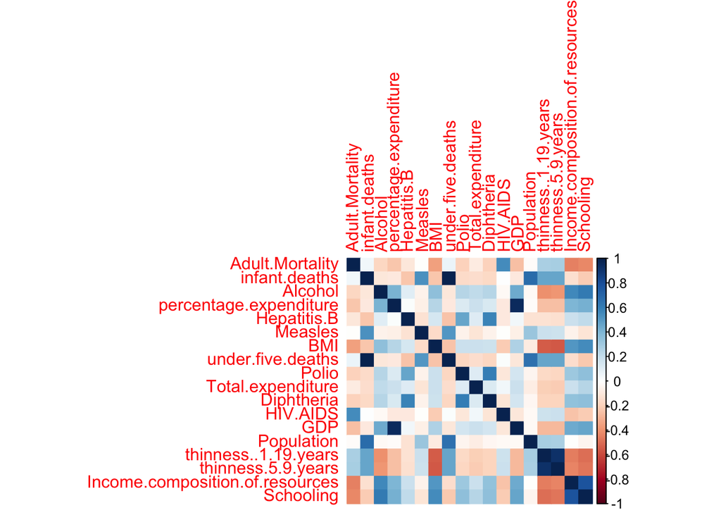

```r
corrplot(cor(data[,-1]), method = 'color')
```

Variables with higher correlations are:

- thinness 1-19 and thinness 5-9 years
- GDP and percentage expenditure
- infant deaths and under five deaths

### Building linear regression model:

Splitting data into training and testing sets:

```r
set.seed(213)
train_indices <- sample(nrow(data), nrow(data) * 0.8)
train_data <- data[train_indices, ]
test_data <- data[-train_indices, ]
```

```r
model <- lm(train_data$Life.expectancy ~ ., data = train_data)
```

```r
#model
#model$coefficients
```

```r
summary(model)
```

```
##
## Call:
## lm(formula = train_data$Life.expectancy ~ ., data = train_data)
##
## Residuals:
##      Min       1Q   Median       3Q      Max
## -1.89682 -0.23346 -0.00183  0.24077  1.35273
##
## Coefficients:
##                                  Estimate Std. Error t value Pr(>|t|)
## (Intercept)                     -0.005312   0.010997  -0.483   0.6291
## Adult.Mortality                 -0.229683   0.014403 -15.947  < 2e-16 ***
## infant.deaths                    1.228368   0.158943   7.728 2.17e-14 ***
## Alcohol                         -0.033096   0.015308  -2.162   0.0308 *
## percentage.expenditure           0.079643   0.042421   1.877   0.0607 .
## Hepatitis.B                     -0.010784   0.014275  -0.755   0.4501
## Measles                         -0.006260   0.012763  -0.490   0.6239
## BMI                              0.085156   0.014726   5.783 9.20e-09 ***
## under.five.deaths               -1.250478   0.155541  -8.040 2.01e-15 ***
## Polio                            0.013901   0.014128   0.984   0.3254
## Total.expenditure                0.023002   0.011627   1.978   0.0481 *
## Diphtheria                       0.037878   0.015763   2.403   0.0164 *
## HIV.AIDS                        -0.321893   0.013441 -23.949  < 2e-16 ***
## GDP                              0.016180   0.043596   0.371   0.7106
## Population                      -0.004136   0.014833  -0.279   0.7804
## thinness..1.19.years             0.005627   0.033649   0.167   0.8672
## thinness.5.9.years              -0.029205   0.033487  -0.872   0.3833
## Income.composition.of.resources  0.213346   0.018975  11.243  < 2e-16 ***
## Schooling                        0.274447   0.020620  13.310  < 2e-16 ***
## ---
## Signif. codes:  0 '***' 0.001 '**' 0.01 '*' 0.05 '.' 0.1 ' ' 1
##
## Residual standard error: 0.3989 on 1300 degrees of freedom
## Multiple R-squared:  0.8412, Adjusted R-squared:  0.839
## F-statistic: 382.7 on 18 and 1300 DF,  p-value: < 2.2e-16
```

It means that we should remove other variables from our model.

Positive coefficients:

- Infant deaths
- Percentage expenditure
- Income
- Schooling
- Diphtheria
- Total.expenditure
- BMI

Negative coefficients:

- Adult Mortality
- HIV AIDS
- Alcohol
- Under five deaths

### Evaluating linear regression model

```r
predictions <- predict(model, newdata = test_data)
```

```r
# Ewaluacja modelu

#mse
mse <- mean((predictions - test_data$Life.expectancy)^2)
#mae
mae <- mean(abs(predictions - test_data$Life.expectancy))
#R^2
ss_residual <- sum((test_data$Life.expectancy - predictions)^2)
ss_total <- sum((test_data$Life.expectancy - mean(test_data$Life.expectancy))^2)
r_squared <- 1 - (ss_residual / ss_total)

# Wyświetlanie wyników
cat("Mean Squared Error (MSE):", mse, "\n")
```

```
## Mean Squared Error (MSE): 0.2012405
```

```r
cat("Mean Absolute Error (MAE):", mae, "\n")
```

```
## Mean Absolute Error (MAE): 0.3485587
```

```r
cat("R-squared:", r_squared, "\n")
```

```
## R-squared: 0.8069492
```

### Building linear regression model with only significant variables

```r
model2 <- lm(train_data$Life.expectancy ~ Adult.Mortality + infant.deaths + Alcohol + percentage.expenditure +
              BMI + under.five.deaths + Total.expenditure + Diphtheria + HIV.AIDS + Income.composition.of.resources + Schooling,data = train_data)
```

```r
summary(model2)
```

```
##
## Call:
## lm(formula = train_data$Life.expectancy ~ Adult.Mortality + infant.deaths +
##     Alcohol + percentage.expenditure + BMI + under.five.deaths +
##     Total.expenditure + Diphtheria + HIV.AIDS + Income.composition.of.resources +
##     Schooling, data = train_data)
##
## Residuals:
##     Min      1Q  Median      3Q     Max
## -1.8984 -0.2262 -0.0052  0.2452  1.3269
##
## Coefficients:
##                                  Estimate Std. Error t value Pr(>|t|)
## (Intercept)                     -0.005918   0.010974  -0.539  0.58979
## Adult.Mortality                 -0.231884   0.014327 -16.185  < 2e-16 ***
## infant.deaths                    1.181292   0.148285   7.966 3.53e-15 ***
## Alcohol                         -0.029250   0.015052  -1.943  0.05220 .
## percentage.expenditure           0.095722   0.013151   7.279 5.79e-13 ***
## BMI                              0.092800   0.013694   6.777 1.85e-11 ***
## under.five.deaths               -1.217450   0.149209  -8.159 7.84e-16 ***
## Total.expenditure                0.024390   0.011503   2.120  0.03416 *
## Diphtheria                       0.038978   0.011931   3.267  0.00112 **
## HIV.AIDS                        -0.322806   0.013366 -24.152  < 2e-16 ***
## Income.composition.of.resources  0.216199   0.018828  11.483  < 2e-16 ***
## Schooling                        0.277211   0.020305  13.652  < 2e-16 ***
## ---
## Signif. codes:  0 '***' 0.001 '**' 0.01 '*' 0.05 '.' 0.1 ' ' 1
##
## Residual standard error: 0.3985 on 1307 degrees of freedom
## Multiple R-squared:  0.8407, Adjusted R-squared:  0.8394
## F-statistic: 627.3 on 11 and 1307 DF,  p-value: < 2.2e-16
```

### Evaluating linear regression model with only significant values

```r
predictions2 <- predict(model2, newdata = test_data)
```

```r
# Ewaluacja modelu

#mse
mse <- mean((predictions2 - test_data$Life.expectancy)^2)
#mae
mae <- mean(abs(predictions2 - test_data$Life.expectancy))
#R^2
ss_residual <- sum((test_data$Life.expectancy - predictions2)^2)
ss_total <- sum((test_data$Life.expectancy - mean(test_data$Life.expectancy))^2)
r_squared <- 1 - (ss_residual / ss_total)

# Wyświetlanie wyników
cat("Mean Squared Error (MSE):", mse, "\n")
```

```
## Mean Squared Error (MSE): 0.2034648
```

```r
cat("Mean Absolute Error (MAE):", mae, "\n")
```

```
## Mean Absolute Error (MAE): 0.3502955
```

```r
cat("R-squared:", r_squared, "\n")
```

```
## R-squared: 0.8048154
```

Values of metrics are almost the same for both models.

### Building logistic regression model

```r
# Calculate the median of life expectancy
threshold <- mean(data$Life.expectancy)

# Create a new binary variable based on the median threshold
data$Life.expectancy.binary <- ifelse(data$Life.expectancy > threshold, 1, 0)
```

```r
# split hte data into training and testing
set.seed(213)
train_indices <- sample(nrow(data), nrow(data) * 0.8)
train_data <- data[train_indices, ]
test_data <- data[-train_indices, ]
```

```r
# Creating the logistic regression model
logistic_model <- glm(Life.expectancy.binary ~ . -Life.expectancy, data = train_data, family = binomial)
# summary of the model
summary(logistic_model)
```

```
##
## Call:
## glm(formula = Life.expectancy.binary ~ . - Life.expectancy, family = binomial,
##     data = train_data)
##
## Deviance Residuals:
##      Min        1Q    Median        3Q       Max
## -2.84764  -0.05994   0.00091   0.31251   2.82660
##
## Coefficients:
##                                  Estimate Std. Error z value Pr(>|z|)
## (Intercept)                      -0.24025    0.52217  -0.460 0.645445
## Adult.Mortality                  -1.92853    0.21325  -9.043  < 2e-16 ***
## infant.deaths                    46.00618   13.15460   3.497 0.000470 ***
## Alcohol                           0.34290    0.16511   2.077 0.037816 *
## percentage.expenditure            8.62549    1.44031   5.989 2.12e-09 ***
## Hepatitis.B                      -0.05802    0.14983  -0.387 0.698588
## Measles                          -0.10122    0.27884  -0.363 0.716604
## BMI                               0.16042    0.15072   1.064 0.287154
## under.five.deaths               -50.79954   14.38209  -3.532 0.000412 ***
## Polio                            -0.17211    0.15567  -1.106 0.268918
## Total.expenditure                 0.35947    0.14753   2.437 0.014823 *
## Diphtheria                        0.05062    0.14740   0.343 0.731302
## HIV.AIDS                         -5.28857    1.04178  -5.076 3.85e-07 ***
## GDP                              -1.43648    0.70998  -2.023 0.043046 *
## Population                       -0.55096    0.29356  -1.877 0.060547 .
## thinness..1.19.years              1.08036    0.48183   2.242 0.024947 *
## thinness.5.9.years               -0.81380    0.47828  -1.702 0.088845 .
## Income.composition.of.resources   0.94261    0.21320   4.421 9.81e-06 ***
## Schooling                         0.65265    0.25417   2.568 0.010236 *
## ---
## Signif. codes:  0 '***' 0.001 '**' 0.01 '*' 0.05 '.' 0.1 ' ' 1
##
## (Dispersion parameter for binomial family taken to be 1)
##
##     Null deviance: 1808.82  on 1318  degrees of freedom
## Residual deviance:  567.56  on 1300  degrees of freedom
## AIC: 605.56
##
## Number of Fisher Scoring iterations: 9
```

- Adult Mortality
- Infant deaths
- Percentage expenditure
- Under five deaths
- Total.expenditure
- HIV AIDS
- thinness..1.19.years
- Income
- Schooling

Significant variables with positive coefficients:

- Infant Deaths
- thinness..1.19.years
- Income
- Schooling
- percentage.expenditure

### Evaluating logistic regression model

```r
# Make predictions on the test set
probabilites <- predict(logistic_model, newdata = test_data, type = "response")
predictions <- ifelse(probabilites > 0.5, 1, 0)
```

```r
# Create a confusion matrix
conf_matrix <- table(Actual = test_data$Life.expectancy.binary, Predicted = predictions)
```

```r
# Print the confusion matrix
print(conf_matrix)
```

```
##       Predicted
## Actual   0   1
##      0 118  17
##      1  16 179
```

```r
# Calculate accuracy
accuracy <- sum(predictions == test_data$Life.expectancy.binary) / length(predictions)
# Calculate precision
precision <- conf_matrix[2, 2] / sum(conf_matrix[, 2])
# Calculate recall
recall <- conf_matrix[2, 2] / sum(conf_matrix[2, ])
# Calculate F1-score
f1_score <- 2 * precision * recall / (precision + recall)
cat("Accuracy:", accuracy, "\n")
```

```
## Accuracy: 0.9
```

```r
cat("Precision:", precision, "\n")
```

```
## Precision: 0.9132653
```

```r
cat("Recall:", recall, "\n")
```

```
## Recall: 0.9179487
```

```r
cat("F1-Score:", f1_score, "\n")
```

```
## F1-Score: 0.915601
```